# cross-validation

Yuqi Miao

11/12/2019

# slides

## Model selection is hard

Lots of times you’re not in the best case, but still have to do something This isn’t an easy thing to do

- For nested models, you have tests

– You have to be worried about multiple comparisons and “fishing”

- For non-nested models, you don’t have tests – AIC / BIC / etc are traditional tools
  - IC : information critieria, telling the goodness of models to different data;
  - Balance goodness of fit with “complexity”

## Questioning fit

- These are basically the same question:

– Is my model not complex enough? Too complex? – Am I underfitting? Overfitting?

– Do I have high bias? High variance?

- Another way to think of this is out-of-sample goodness of fit:

– Will my model `generalize` to future datasets?

## cross validation

- randomly assigned the data into training/test dataset( usualy ratio is `80/20`)
- result is RMSE for prediction in test group

##?? why no fold?

## Comes up a lot in “modern” methods

– Automated variable selection `(e.g. lasso)` – Additive models – Regression trees

```r
library(tidyverse)
library(modelr)
library(mgcv)
```

# CV by hand

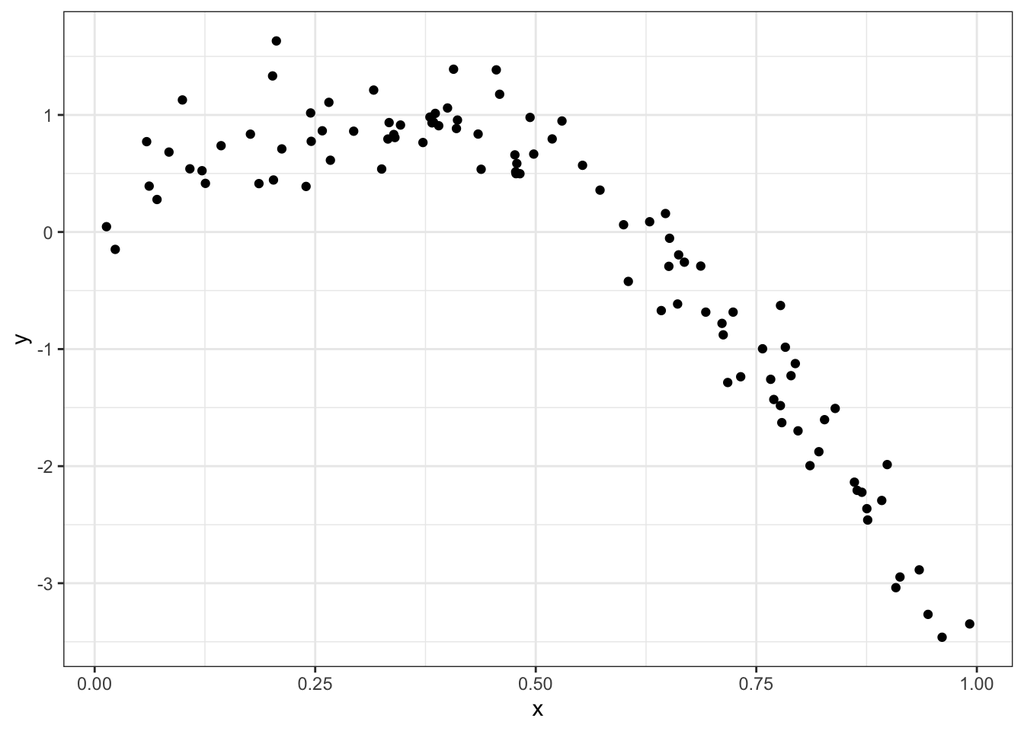

```r
set.seed(1)
nonlin_df =
  tibble(
    id = 1:100,
    x = runif(100, 0, 1),
    y = 1 - 10 * (x - .3) ^ 2 + rnorm(100, 0, .3)
  )

nonlin_df %>%
  ggplot(aes(x = x, y = y)) +
  geom_point() + theme_bw()
```

## split data using `anti_join`

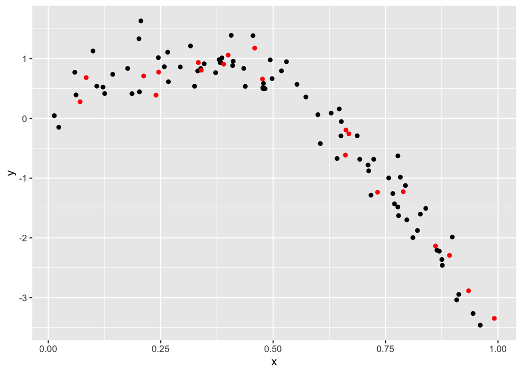

```r
train_df = sample_frac(nonlin_df, size = 0.8) ## first sample training dataset
test_df = anti_join(nonlin_df, train_df, by = "id") # then use anti_join() to get test datset

ggplot(train_df, aes(x = x, y = y)) +
  geom_point() +
  geom_point(data = test_df, color = "red")
```

# Fit 3 models of varying goodness

```r
linear_mod = lm(y ~ x, data = train_df)
smooth_mod = mgcv::gam(y ~ s(x), data = train_df) ##use mgcv::gam for non-linear models
wiggly_mod = mgcv::gam(y ~ s(x, k = 30), sp = 10e-6, data = train_df)
```

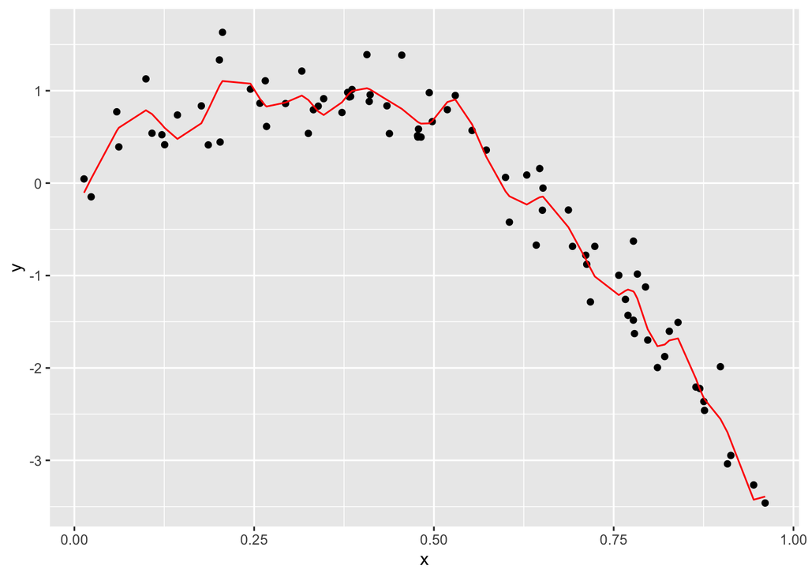

```r
train_df %>%
  add_predictions(wiggly_mod) %>% ## from modelr package, can add predictions from models to the dataset directly
  ggplot(aes(x = x, y = y)) + geom_point() +
  geom_line(aes(y = pred), color = "red")
```

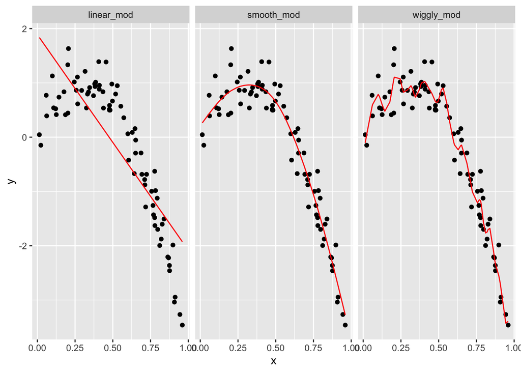

```r
train_df %>%
  gather_predictions(linear_mod, smooth_mod, wiggly_mod) %>% ## gather together predictions results
  mutate(model = fct_inorder(model)) %>%
  ggplot(aes(x = x, y = y)) +
  geom_point() +
  geom_line(aes(y = pred), color = "red") +
  facet_wrap(~model)
```

## test results

```r
rmse(linear_mod, test_df)
```

```
## [1] 0.7052956
```

```r
rmse(smooth_mod,test_df)
```

```
## [1] 0.2221774
```

```r
rmse(wiggly_mod,test_df)
```

```
## [1] 0.289051
```

```r
rmse(wiggly_mod,train_df)
```

```
## [1] 0.2498309
```

```r
rmse(smooth_mod,train_df)
```

```
## [1] 0.2874834
```

- Choose the prediction score relatively instead of focusing on the absolute value.
- wiggly_mod is overfitting to the training dataset, not perform as well as smooth to predict.
- when the variables ammount is large, there is a trend to overfit; But wiggly is useful to select relative important variables.

# Using modelr to CV

```r
cv_df =
    crossv_mc(nonlin_df,100) ## create 100 pair of train and test datasets
```

## note about resample

```r
cv_df %>% pull(train) %>% .[[8]] %>% as_tibble
```

```
## # A tibble: 79 x 3
##       id     x      y
##    <int> <dbl>  <dbl>
##  1     1 0.266  1.11
##  2     4 0.908 -3.04
##  3     5 0.202  1.33
##  4     7 0.945 -3.27
##  5    11 0.206  1.63
##  6    12 0.177  0.836
##  7    13 0.687 -0.291
##  8    15 0.770 -1.43
##  9    16 0.498  0.666
## 10    17 0.718 -1.29
## # … with 69 more rows
```

```r
# it saves the data once and stores the indexes for each training / testing split using a resample object, resample just give the row index, need to use as_tibble to make it a dataset

cv_df =
  cv_df %>%
  mutate(
    train = map(train, as_tibble),
    test = map(test, as_tibble))
```

## using `mutate + map & map2` to fit the model and predict

```r
cv_df =
  cv_df %>%
  mutate(linear_mod  = map(train, ~lm(y ~ x, data = .x)),
         smooth_mod  = map(train, ~mgcv::gam(y ~ s(x), data = .x)),
         wiggly_mod  = map(train, ~gam(y ~ s(x, k = 30), sp = 10e-6, data = .x))) %>%
  mutate(rmse_linear = map2_dbl(linear_mod, test, ~rmse(model = .x, data = .y)),
         rmse_smooth = map2_dbl(smooth_mod, test, ~rmse(model = .x, data = .y)),
         rmse_wiggly = map2_dbl(wiggly_mod, test, ~rmse(model = .x, data = .y)))
```

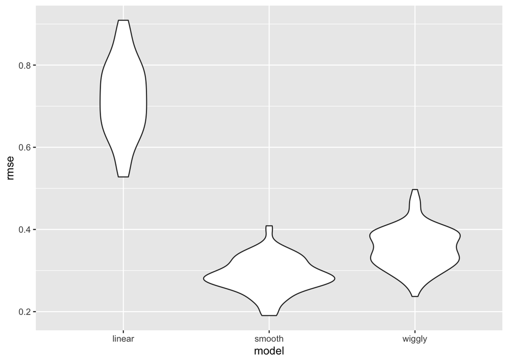

```r
cv_df %>%
  select(starts_with("rmse")) %>%
  pivot_longer(
    everything(),
    names_to = "model",
    values_to = "rmse",
    names_prefix = "rmse_") %>%
  mutate(model = fct_inorder(model,rmse)) %>%
  ggplot(aes(x = model, y = rmse)) + geom_violin()
```

```r
child_growth = read_csv("nepalese_children.csv")
```